# Your Digest for Tuesday, Oct 01, 2024 09:59 PM

# Abdominal pain

Organs to consider

1. Liver
2. GI tract and adnexa
3. Gall bladder
4. Pancreas
5. Kidneys
6. Bladder
7. Aorta

With abdominal pain, the **starting point is location**.

# what I've learned on 2024-10-01

## Things to read

- differential diagnosis of weight loss and loss of appetite
- what is the mechanism of vomiting during other illness?

## 3 things you did well

## 3 things you can do better

# ECG quiz

**How to use Diagnostic testing**:

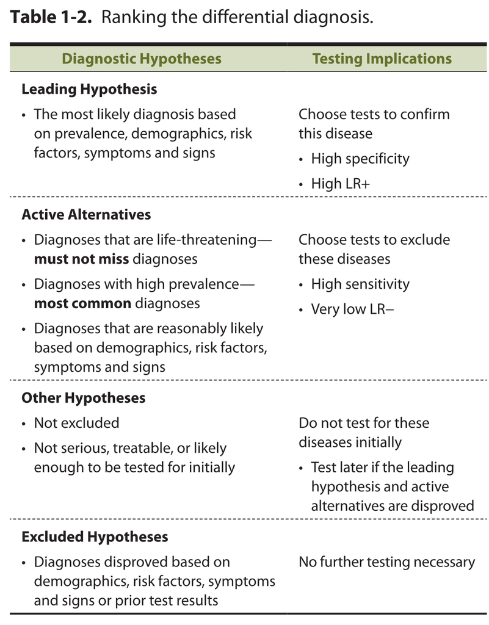

When managing a patient:  
remember

1. leading diagnosis
2. must not miss diagnoses
3. other differentials

Always come up with some type of management plan before "senior opinion".

What were doing on medicine is trying to see if the patient fits into a previous "diagnosis" (i.e a problem that someone has encountered before) and then treating the patient in the same way that other people have treated the same condition. ( With adjustments tailored to the patient). That's the whole point of making a "diagnosis".

During morning rounds,

- For previously admitted patients, check the problem list.
- for new patients, try to find the problem. Accept that you can't find a single diagnosis with history taking alone. Usually, you can narrow it down to a particular system and a particular symptom progression.

**Haemoptysis**:

- Caused by either bleeding from a large blood vessel (malignancy, bronchiectasis, TB etc) or a small blood vessel (small vasculitis) or normal blood vessels but patient has coagulopathy - but that's less common.

**Patient analysis**:  
History / Examination / DDs / Problem list.

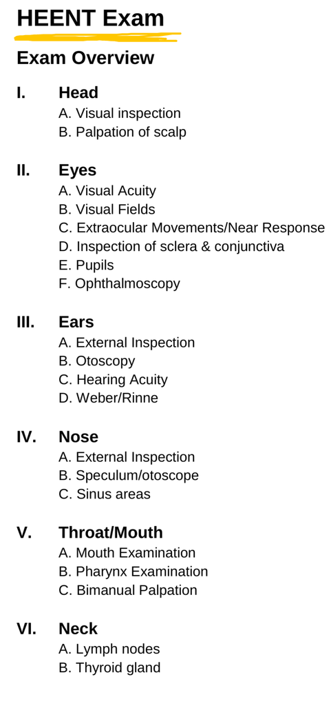